# data summary report

2025-01-17

This report provides an overview of the dataset from the **Douglas-fir retrospective monitoring** project, focusing on four key aspects:  
1. Data Completeness: Assessment of missing or incomplete data. (project)  
2. Data Summary: Summary statistics and descriptive insights into the dataset. (project-species)  
3. site-level data summary and scale issues (site-species)  
4. Correlation Analysis and quality assessment code: Evaluation of autocorrelation and correlation with the mean chronology for each series. It includes quality assessment codes generated by the CFS_qa() function. (radii-species)

The report aims to provide a comprehensive overview of the dataset’s quality and characteristics, analyzed at the levels of species, species-site, and species-radius.

### 1. data completeness

This table presents the completeness of each variable of the whole dataset as a percentage. A value of 0 indicates no effective data. Please carefully verify that all required data has been included in the submission.

| var | pct |
| --- | --- |
| tr1_submission_id | 100 |
| tr1_project_name | 100 |
| tr1_description | 100 |
| tr1_year_range | 100 |
| tr1_reference | 100 |
| tr1_open_data | 100 |
| tr1_contact1 | 100 |
| tr1_contact2 | 100 |
| tr2_site_id | 100 |
| tr2_latitude | 100 |
| tr2_longitude | 100 |
| tr2_datasource | 100 |
| tr2_investigators | 100 |

| var | pct |
| --- | --- |
| tr2_province_iso_code | 100.0 |
| tr3_tree_id | 100.0 |
| tr3_species | 100.0 |
| tr4_meas_no | 0.0 |
| tr4_meas_date | 100.0 |
| tr4_status | 100.0 |
| tr4_dbh_cm | 98.8 |
| tr4_ht_tot_m | 99.2 |
| tr5_sample_id | 100.0 |
| tr5_sample_type | 100.0 |
| tr5_sample_ht_m | 0.0 |
| tr5_sample_diameter_cm | 0.0 |

| var | pct |
| --- | --- |
| tr6_radius_id | 100.0 |
| tr6_cofecha_id | 0.0 |
| tr6_ring_meas_method | 100.0 |
| tr6_crossdating_visual | 100.0 |
| tr6_crossdating_validation | 100.0 |
| tr6_age_corrected | 0.0 |
| tr6_bark_thickness_mm | 0.0 |
| tr6_radius_inside_cm | 100.0 |
| tr6_dtc_measured_mm | 100.0 |
| tr6_dtc_estimated_mm | 65.8 |
| tr6_rw_ystart | 100.0 |
| tr6_rw_yend | 100.0 |
| tr6_comments | 0.0 |

### 2. data summary

This section presents key summary statistics, including spatial and temporal ranges, summary of ring width measurements, diameter at breast height (DBH), and height (if available), categorized by species.

In this dataset, there’s(’re) **1** species: **PSEUMEN**

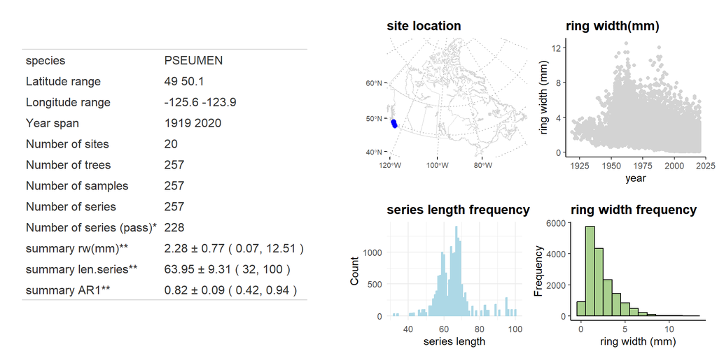

*Number of series that passed the test of CFS_qa() on differentiated series

**The values refer to mean ± sd (min, max)

### 3. site-level data summary

This section presents site-level data summaries, including a figure showing ring width measurements over time and a table with key statistics.

#### PSEUMEN

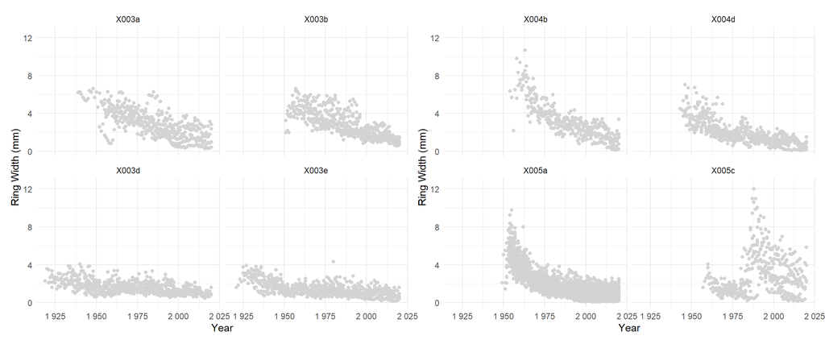

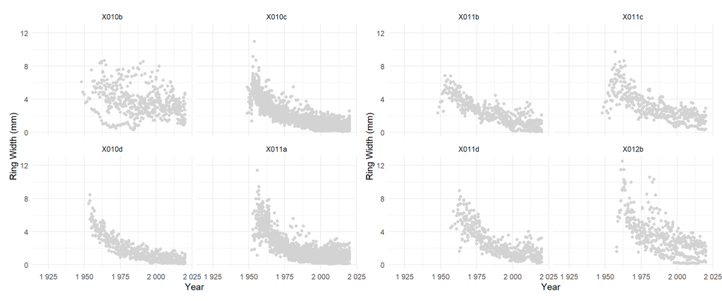

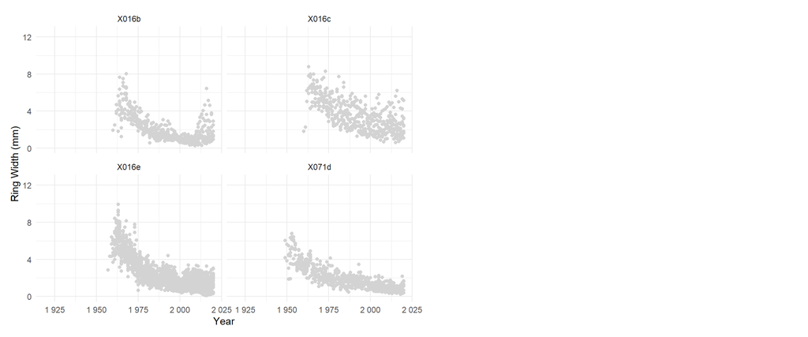

This table provides a site-level summary, including the series length, raw ring width measurements, the median ring width, the median ring width of its 10 closest neighbors, and the ratio between them. This offers insights into potential outliers caused by scaling issues.

PSEUMEN

| uid_site | site_id | lon | lat | Nb. trees | len.series** | rw(mm)** | median rw(mm) | neigh median rw(mm) | ratio_rw* |
| --- | --- | --- | --- | --- | --- | --- | --- | --- | --- |
| 1 | X003b | -123.9337 | 48.96656 | 8 | 63.75 ± 6.34 ( 54, 70 ) | 2.8 ± 0.63 ( 0.58, 6.64 ) | 2.4625 | 1.50750 | 1.6 |
| 2 | X003a | -123.9339 | 48.96615 | 7 | 63.71 ± 4.23 ( 57, 68 ) | 2.94 ± 0.7 ( 0.28, 6.64 ) | 3.0300 | 1.50750 | 2.0 |
| 3 | X003d | -123.8980 | 49.04082 | 7 | 89.57 ± 6.83 ( 81, 98 ) | 1.6 ± 0.36 ( 0.45, 4.06 ) | 1.4500 | 1.89125 | 0.8 |
| 4 | X003e | -123.8966 | 49.04087 | 7 | 91 ± 6.19 ( 83, 100 ) | 1.45 ± 0.38 ( 0.15, 4.32 ) | 1.3650 | 1.89125 | 0.7 |
| 5 | X004b | -123.9952 | 49.05755 | 6 | 60.5 ± 4.09 ( 56, 67 ) | 3.18 ± 0.61 ( 0.15, 10.66 ) | 2.8425 | 1.50750 | 1.9 |
| 6 | X004d | -123.9633 | 49.05906 | 8 | 68.88 ± 11.91 ( 41, 78 ) | 1.91 ± 0.19 ( 0.09, 7.04 ) | 1.5650 | 1.83375 | 0.9 |
| 7 | X005a | -124.7889 | 49.41944 | 50 | 63.02 ± 6.04 ( 46, 72 ) | 1.79 ± 0.36 ( 0.07, 9.79 ) | 1.2750 | 1.82375 | 0.7 |
| 8 | X005c | -124.7485 | 49.42990 | 8 | 53.62 ± 7.27 ( 42, 64 ) | 2.78 ± 1.01 ( 0.15, 12.03 ) | 2.2175 | 1.57000 | 1.4 |
| 9 | X010c | -124.8056 | 49.42778 | 31 | 68.23 ± 2.33 ( 61, 72 ) | 1.92 ± 0.38 ( 0.08, 10.98 ) | 1.3300 | 1.82375 | 0.7 |
| 10 | X010b | -124.7406 | 49.42476 | 8 | 61.12 ± 7.3 ( 48, 73 ) | 3.75 ± 1.14 ( 0.3, 8.65 ) | 3.4900 | 1.57000 | 2.2 |
| 11 | X010d | -124.8184 | 49.43054 | 7 | 65.86 ± 1.68 ( 63, 68 ) | 1.91 ± 0.3 ( 0.08, 8.44 ) | 1.3500 | 1.82375 | 0.7 |
| 12 | X011a | -125.5528 | 50.04167 | 28 | 60.93 ± 8.62 ( 32, 69 ) | 2.03 ± 0.47 ( 0.08, 11.42 ) | 1.5700 | 1.85750 | 0.8 |
| 13 | X011c | -125.5210 | 50.04691 | 6 | 68.67 ± 2.42 ( 66, 73 ) | 3.15 ± 0.66 ( 0.29, 9.71 ) | 2.7525 | 1.79125 | 1.5 |
| 14 | X011b | -125.5213 | 50.04673 | 7 | 65.86 ± 4.98 ( 59, 73 ) | 2.36 ± 0.36 ( 0.08, 6.84 ) | 1.9900 | 1.79125 | 1.1 |
| 15 | X011d | -125.5184 | 50.06773 | 8 | 58.5 ± 2.78 ( 55, 64 ) | 2.55 ± 0.73 ( 0.15, 8.93 ) | 1.8250 | 1.82375 | 1.0 |
| 16 | X012b | -125.5709 | 50.04237 | 8 | 55.75 ± 7.11 ( 43, 63 ) | 3.36 ± 0.88 ( 0.11, 12.51 ) | 2.8550 | 1.79125 | 1.6 |
| 17 | X016e | -125.4861 | 49.95278 | 29 | 58.55 ± 3.01 ( 48, 64 ) | 2.48 ± 0.41 ( 0.1, 9.94 ) | 1.8900 | 1.79125 | 1.1 |
| 18 | X016c | -125.4847 | 49.94777 | 8 | 56.62 ± 3.7 ( 50, 61 ) | 3.57 ± 0.82 ( 0.6, 8.77 ) | 2.9950 | 1.79125 | 1.7 |
| 19 | X016b | -125.4950 | 49.94418 | 8 | 57.75 ± 1.91 ( 55, 61 ) | 2.11 ± 0.29 ( 0.25, 8.04 ) | 1.5750 | 1.85750 | 0.8 |
| 20 | X071d | -125.5010 | 50.03760 | 8 | 68.88 ± 2.8 ( 64, 72 ) | 2.01 ± 0.32 ( 0.24, 6.77 ) | 1.7575 | 1.85750 | 0.9 |

*ratio between median of rw of the site and median of rw of its 10 nearest neighbors.

**The values refer to mean ± sd (min, max)

### 4. Correlation and quality assessment code

This table provides a summary for each series, including raw ring width measurements, autocorrelation, and correlation with the master chronology for both raw and differentiated data, and quality assessment code (qa_code) which was derived from the CFS_qa() function. The master chronology includes all the series with qa_code “pass”.

PSEUMEN

| uid_site | uid_radius | year from | year to | len series | raw AR1* | raw corr_mean*& | trt AR1** | trt corr_mean**& | qa_code** |
| --- | --- | --- | --- | --- | --- | --- | --- | --- | --- |
| 1 | 1 | 1961 | 2020 | 60 | 0.88 | 0.73 ( 59, 0 ) | -0.38 | 0.54 ( 59, 0 ) | pass |
| 1 | 2 | 1956 | 2020 | 65 | 0.89 | 0.93 ( 64, 0 ) | -0.40 | 0.45 ( 64, 0 ) | pass |
| 1 | 3 | 1965 | 2020 | 56 | 0.87 | 0.88 ( 55, 0 ) | -0.38 | 0.45 ( 55, 0 ) | pass |
| 1 | 4 | 1951 | 2020 | 70 | 0.88 | 0.81 ( 69, 0 ) | -0.43 | 0.51 ( 69, 0 ) | pass |
| 1 | 5 | 1951 | 2020 | 70 | 0.85 | 0.85 ( 69, 0 ) | -0.36 | 0.25 ( 69, 0.04 ) | Fail |
| 1 | 6 | 1952 | 2020 | 69 | 0.88 | 0.94 ( 68, 0 ) | -0.51 | 0.52 ( 68, 0 ) | pass |
| 1 | 7 | 1955 | 2020 | 66 | 0.85 | 0.88 ( 65, 0 ) | -0.27 | 0.34 ( 65, 0.01 ) | pass |
| 1 | 8 | 1967 | 2020 | 54 | 0.79 | 0.78 ( 53, 0 ) | -0.45 | 0.51 ( 53, 0 ) | pass |
| 2 | 9 | 1964 | 2020 | 57 | 0.80 | 0.88 ( 56, 0 ) | -0.07 | 0.42 ( 56, 0 ) | pass |
| 2 | 10 | 1953 | 2020 | 68 | 0.92 | 0.93 ( 67, 0 ) | -0.26 | 0.09 ( 67, 0.49 ) | Fail |
| 2 | 11 | 1939 | 2002 | 64 | 0.90 | 0.44 ( 63, 0 ) | -0.47 | 0.02 ( 63, 0.85 ) | Fail |
| 2 | 12 | 1952 | 2018 | 67 | 0.82 | 0.31 ( 66, 0.01 ) | -0.12 | 0.1 ( 66, 0.44 ) | Fail |
| 2 | 13 | 1957 | 2020 | 64 | 0.91 | 0.95 ( 63, 0 ) | -0.32 | 0.57 ( 63, 0 ) | pass |
| 2 | 14 | 1954 | 2020 | 67 | 0.85 | 0.88 ( 66, 0 ) | -0.36 | 0.4 ( 66, 0 ) | pass |
| 2 | 15 | 1956 | 2014 | 59 | 0.89 | 0.53 ( 58, 0 ) | -0.15 | -0.23 ( 58, 0.08 ) | Fail |
| 3 | 16 | 1931 | 2019 | 89 | 0.73 | 0.14 ( 88, 0.18 ) | -0.12 | 0.39 ( 88, 0 ) | pass |
| 3 | 17 | 1936 | 2020 | 85 | 0.55 | -0.45 ( 84, 0 ) | -0.45 | 0.08 ( 84, 0.49 ) | Fail |
| 3 | 18 | 1923 | 2020 | 98 | 0.64 | 0.17 ( 97, 0.11 ) | -0.23 | 0.2 ( 97, 0.05 ) | borderline |
| 3 | 19 | 1934 | 2016 | 83 | 0.72 | 0.32 ( 82, 0 ) | -0.39 | 0.27 ( 82, 0.02 ) | pass |
| 3 | 20 | 1919 | 2013 | 95 | 0.76 | 0.44 ( 94, 0 ) | -0.28 | 0.43 ( 94, 0 ) | pass |
| 3 | 21 | 1940 | 2020 | 81 | 0.84 | 0.5 ( 80, 0 ) | -0.28 | 0.37 ( 80, 0 ) | pass |
| 3 | 22 | 1921 | 2016 | 96 | 0.76 | 0.18 ( 95, 0.08 ) | -0.56 | 0.41 ( 95, 0 ) | pass |
| 4 | 23 | 1925 | 2019 | 95 | 0.73 | 0.37 ( 94, 0 ) | -0.44 | 0.23 ( 94, 0.03 ) | pass |
| 4 | 24 | 1932 | 2020 | 89 | 0.77 | 0.48 ( 88, 0 ) | -0.40 | 0.26 ( 88, 0.02 ) | borderline |
| 4 | 25 | 1930 | 2020 | 91 | 0.68 | 0.12 ( 90, 0.24 ) | -0.35 | 0.28 ( 90, 0.01 ) | pass |
| 4 | 26 | 1921 | 2020 | 100 | 0.89 | 0.19 ( 99, 0.06 ) | -0.34 | 0.51 ( 99, 0 ) | pass |
| 4 | 27 | 1926 | 2020 | 95 | 0.78 | 0.23 ( 94, 0.03 ) | -0.31 | 0.37 ( 94, 0 ) | pass |
| 4 | 28 | 1932 | 2014 | 83 | 0.70 | 0.15 ( 82, 0.18 ) | -0.44 | 0.51 ( 82, 0 ) | pass |
| 4 | 29 | 1933 | 2016 | 84 | 0.55 | 0.05 ( 83, 0.64 ) | -0.37 | 0.34 ( 83, 0 ) | pass |
| 5 | 30 | 1965 | 2020 | 56 | 0.79 | 0.82 ( 55, 0 ) | -0.25 | 0.4 ( 55, 0 ) | pass |

[output cut: 227 more lines]

*developed from raw series

**developed from differentiated series

&correlation with master chronology, the value represents correlation (N, p-value)